# EDA & Feature Engineering of the PUBG Dataset

[figure not shown]

```python
import numpy as np
import pandas as pd
import matplotlib.pyplot as plt
import seaborn as sns
import warnings
from lightgbm import LGBMRegressor

import gc
import time
import random
import eli5
from eli5.sklearn import PermutationImportance
import shap
from smart_open import smart_open
import os
from configparser import ConfigParser

warnings.filterwarnings("ignore")
```

```python
def reload():
    config = ConfigParser()
    config_file = os.path.join(os.path.dirname('__file__'), 'config.ini')
    config.read(config_file)
    default = config['aws.data']
    aws_key = default['accessKey']
    aws_secret = default['secretAccessKey']

    bucket_name = 'pubg-dataset-files'
    object_key = 'final_train.csv'

    path = 's3://{}:{}@{}/{}'.format(aws_key, aws_secret, bucket_name, object_key)
    gc.collect()
    df = pd.read_csv(smart_open(path))
    invalid_match_ids = df[df['winPlacePerc'].isna()]['matchId'].values
    df = df[-df['matchId'].isin(invalid_match_ids)]
    return df
```

```python
# Memory saving function credit to https://www.kaggle.com/gemartin/load-data-reduce-memory-usage
def reduce_mem_usage(df):
    """ iterate through all the columns of a dataframe and modify the data type
        to reduce memory usage.
    """
    for col in df.columns:
        col_type = df[col].dtype

        if col_type != object:
            c_min = df[col].min()
            c_max = df[col].max()
            if str(col_type)[:3] == 'int':
                if c_min > np.iinfo(np.int8).min and c_max < np.iinfo(np.int8).max:
                    df[col] = df[col].astype(np.int8)
                elif c_min > np.iinfo(np.int16).min and c_max < np.iinfo(np.int16).max:
                    df[col] = df[col].astype(np.int16)
                elif c_min > np.iinfo(np.int32).min and c_max < np.iinfo(np.int32).max:
                    df[col] = df[col].astype(np.int32)
                elif c_min > np.iinfo(np.int64).min and c_max < np.iinfo(np.int64).max:
                    df[col] = df[col].astype(np.int64)
            else:
                if c_min > np.finfo(np.float16).min and c_max < np.finfo(np.float16).max:
                    df[col] = df[col].astype(np.float16)
                elif c_min > np.finfo(np.float32).min and c_max < np.finfo(np.float32).max:
                    df[col] = df[col].astype(np.float32)
                else:
                    df[col] = df[col].astype(np.float64)
    return df
```

- **groupId** - Integer ID to identify a group within a match. If the same group of players plays in different matches, they will have a different groupId each time.
- **matchId** - Integer ID to identify match. There are no matches that are in both the training and testing set.
- **assists** - Number of enemy players this player damaged that were killed by teammates.
- **boosts** - Number of boost items used.
- **damageDealt** - Total damage dealt. Note: Self inflicted damage is subtracted.
- **DBNOs** - Number of enemy players knocked.
- **headshotKills** - Number of enemy players killed with headshots.
- **heals** - Number of healing items used.
- **killPlace** - Ranking in match of number of enemy players killed.
- **killPoints** - Kills-based external ranking of player. (Think of this as an Elo ranking where only kills matter.)
- **kills** - Number of enemy players killed.
- **killStreaks** - Max number of enemy players killed in a short amount of time.
- **longestKill** - Longest distance between player and player killed at time of death. This may be misleading, as downing a - player and driving away may lead to a large longestKill stat.
- **maxPlace** - Worst placement we have data for in the match. This may not match with numGroups, as sometimes the data skips over placements.
- **numGroups** - Number of groups we have data for in the match.
- **revives** - Number of times this player revived teammates.
- **rideDistance** - Total distance traveled in vehicles measured in meters.
- **roadKills** - Number of kills while in a vehicle.
- **swimDistance** - Total distance traveled by swimming measured in meters.
- **teamKills** - Number of times this player killed a teammate.
- **vehicleDestroys** - Number of vehicles destroyed.
- **walkDistance** - Total distance traveled on foot measured in meters.
- **weaponsAcquired** - Number of weapons picked up.
- **winPoints** - Win-based external ranking of player. (Think of this as an Elo ranking where only winning matters.)
- **winPlacePerc** - The target of prediction. This is a percentile winning placement, where 1 corresponds to 1st place, and 0 corresponds to last place in the match. It is calculated off of maxPlace, not numGroups, so it is possible to have missing chunks in a match.

```python
train = pd.read_csv('./train_v3.csv')
invalid_match_ids = train[train['winPlacePerc'].isna()]['matchId'].values
train = train[-train['matchId'].isin(invalid_match_ids)]

train=reduce_mem_usage(train)
```

```python
train.info()
```

```
<class 'pandas.core.frame.DataFrame'>
Int64Index: 4444776 entries, 0 to 4444775
Data columns (total 30 columns):
Unnamed: 0         int32
Id                 object
groupId            object
matchId            object
assists            int8
boosts             int8
damageDealt        float16
DBNOs              int8
headshotKills      int8
heals              int8
killPlace          int8
killPoints         int16
kills              int8
killStreaks        int8
longestKill        float16
matchDuration      int16
matchType          object
maxPlace           int8
numGroups          int8
rankPoints         int16
revives            int8
rideDistance       float16
roadKills          int8
swimDistance       float16
teamKills          int8
vehicleDestroys    int8
walkDistance       float16
weaponsAcquired    int8
winPoints          int16
winPlacePerc       float16
dtypes: float16(6), int16(4), int32(1), int8(15), object(4)
memory usage: 334.9+ MB
```

```python
train.head()
```

|  | Unnamed: 0 | Id | groupId | matchId | assists | boosts | damageDealt | DBNOs | headshotKills | heals | ... | revives | rideDistance | roadKills | swimDistance | teamKills | vehicleDestroys | walkDistance | weaponsAcquired | winPoints | winPlacePerc |
| --- | --- | --- | --- | --- | --- | --- | --- | --- | --- | --- | --- | --- | --- | --- | --- | --- | --- | --- | --- | --- | --- |
| 0 | 0 | 7f96b2f878858a | 4d4b580de459be | a10357fd1a4a91 | 0 | 0 | 0.00000 | 0 | 0 | 0 | ... | 0 | 0.000000 | 0 | 0.000000 | 0 | 0 | 244.75 | 1 | 1466 | 0.444336 |
| 1 | 1 | eef90569b9d03c | 684d5656442f9e | aeb375fc57110c | 0 | 0 | 91.50000 | 0 | 0 | 0 | ... | 0 | 0.004501 | 0 | 11.039062 | 0 | 0 | 1434.00 | 5 | 0 | 0.640137 |
| 2 | 2 | 1eaf90ac73de72 | 6a4a42c3245a74 | 110163d8bb94ae | 1 | 0 | 68.00000 | 0 | 0 | 0 | ... | 0 | 0.000000 | 0 | 0.000000 | 0 | 0 | 161.75 | 2 | 0 | 0.775391 |
| 3 | 3 | 4616d365dd2853 | a930a9c79cd721 | f1f1f4ef412d7e | 0 | 0 | 32.90625 | 0 | 0 | 0 | ... | 0 | 0.000000 | 0 | 0.000000 | 0 | 0 | 202.75 | 3 | 0 | 0.166748 |
| 4 | 4 | 315c96c26c9aac | de04010b3458dd | 6dc8ff871e21e6 | 0 | 0 | 100.00000 | 0 | 0 | 0 | ... | 0 | 0.000000 | 0 | 0.000000 | 0 | 0 | 49.75 | 2 | 0 | 0.187500 |

5 rows × 30 columns

```python
train.describe()
```

|  | Unnamed: 0 | assists | boosts | damageDealt | DBNOs | headshotKills | heals | killPlace | killPoints | kills | ... | revives | rideDistance | roadKills | swimDistance | teamKills | vehicleDestroys | walkDistance | weaponsAcquired | winPoints | winPlacePerc |
| --- | --- | --- | --- | --- | --- | --- | --- | --- | --- | --- | --- | --- | --- | --- | --- | --- | --- | --- | --- | --- | --- |
| count | 4.444776e+06 | 4.444776e+06 | 4.444776e+06 | 4.444776e+06 | 4.444776e+06 | 4.444776e+06 | 4.444776e+06 | 4.444776e+06 | 4.444776e+06 | 4.444776e+06 | ... | 4.444776e+06 | 4.444776e+06 | 4.444776e+06 | 4444776.0 | 4.444776e+06 | 4.444776e+06 | 4444776.000 | 4.444776e+06 | 4.444776e+06 | 4.444776e+06 |
| mean | 2.223500e+06 | 2.331506e-01 | 1.107019e+00 | NaN | 6.575814e-01 | 2.261565e-01 | 1.368316e+00 | 4.760904e+01 | 5.050399e+02 | 9.223331e-01 | ... | 1.646675e-01 | NaN | 3.481165e-03 | NaN | 2.383697e-02 | 7.917834e-03 | NaN | 3.655317e+00 | 6.064665e+02 | NaN |
| std | 1.283730e+06 | 5.855928e-01 | 1.715693e+00 | NaN | 1.142542e+00 | 5.953900e-01 | 2.667661e+00 | 2.746364e+01 | 6.275373e+02 | 1.541627e+00 | ... | 4.720995e-01 | NaN | 7.217387e-02 | NaN | 1.672142e-01 | 9.261150e-02 | NaN | 2.419723e+00 | 7.397016e+02 | 0.000000e+00 |
| min | 0.000000e+00 | 0.000000e+00 | 0.000000e+00 | 0.000000e+00 | 0.000000e+00 | 0.000000e+00 | 0.000000e+00 | 1.000000e+00 | 0.000000e+00 | 0.000000e+00 | ... | 0.000000e+00 | 0.000000e+00 | 0.000000e+00 | 0.0 | 0.000000e+00 | 0.000000e+00 | 0.000 | 0.000000e+00 | 0.000000e+00 | 0.000000e+00 |
| 25% | 1.111765e+06 | 0.000000e+00 | 0.000000e+00 | 0.000000e+00 | 0.000000e+00 | 0.000000e+00 | 0.000000e+00 | 2.400000e+01 | 0.000000e+00 | 0.000000e+00 | ... | 0.000000e+00 | 0.000000e+00 | 0.000000e+00 | 0.0 | 0.000000e+00 | 0.000000e+00 | 155.375 | 2.000000e+00 | 0.000000e+00 | 1.999512e-01 |
| 50% | 2.223504e+06 | 0.000000e+00 | 0.000000e+00 | 8.418750e+01 | 0.000000e+00 | 0.000000e+00 | 0.000000e+00 | 4.700000e+01 | 0.000000e+00 | 0.000000e+00 | ... | 0.000000e+00 | 0.000000e+00 | 0.000000e+00 | 0.0 | 0.000000e+00 | 0.000000e+00 | 686.000 | 3.000000e+00 | 0.000000e+00 | 4.582520e-01 |
| 75% | 3.335240e+06 | 0.000000e+00 | 2.000000e+00 | 1.860000e+02 | 1.000000e+00 | 0.000000e+00 | 2.000000e+00 | 7.100000e+01 | 1.172000e+03 | 1.000000e+00 | ... | 0.000000e+00 | 2.146301e-01 | 0.000000e+00 | 0.0 | 0.000000e+00 | 0.000000e+00 | 1976.000 | 5.000000e+00 | 1.495000e+03 | 7.407227e-01 |
| max | 4.446965e+06 | 1.700000e+01 | 3.300000e+01 | 3.408000e+03 | 3.300000e+01 | 2.300000e+01 | 3.900000e+01 | 1.010000e+02 | 2.170000e+03 | 3.000000e+01 | ... | 3.900000e+01 | 1.993600e+04 | 1.000000e+01 | 1980.0 | 1.200000e+01 | 5.000000e+00 | 9992.000 | 7.800000e+01 | 2.013000e+03 | 1.000000e+00 |

8 rows × 26 columns

Now, let's check if there are any missing data.

```python
train.isna().sum()
```

```
Unnamed: 0         0
Id                 0
groupId            0
matchId            0
assists            0
boosts             0
damageDealt        0
DBNOs              0
headshotKills      0
heals              0
killPlace          0
killPoints         0
kills              0
killStreaks        0
longestKill        0
matchDuration      0
matchType          0
maxPlace           0
numGroups          0
rankPoints         0
revives            0
rideDistance       0
roadKills          0
swimDistance       0
teamKills          0
vehicleDestroys    0
walkDistance       0
weaponsAcquired    0
winPoints          0
winPlacePerc       0
dtype: int64
```

Ok, now that we have a glimpse of the data, let's explore them.

## Analysis on the basis of Kill count

```python
print("The average person kills {:.4f} players, 99% of people have {} kills or less, while the most kills ever recorded is {}.".format(train['kills'].mean(),train['kills'].quantile(0.99), train['kills'].max()))
```

```
The average person kills 0.9223 players, 99% of people have 7.0 kills or less, while the most kills ever recorded is 30.
```

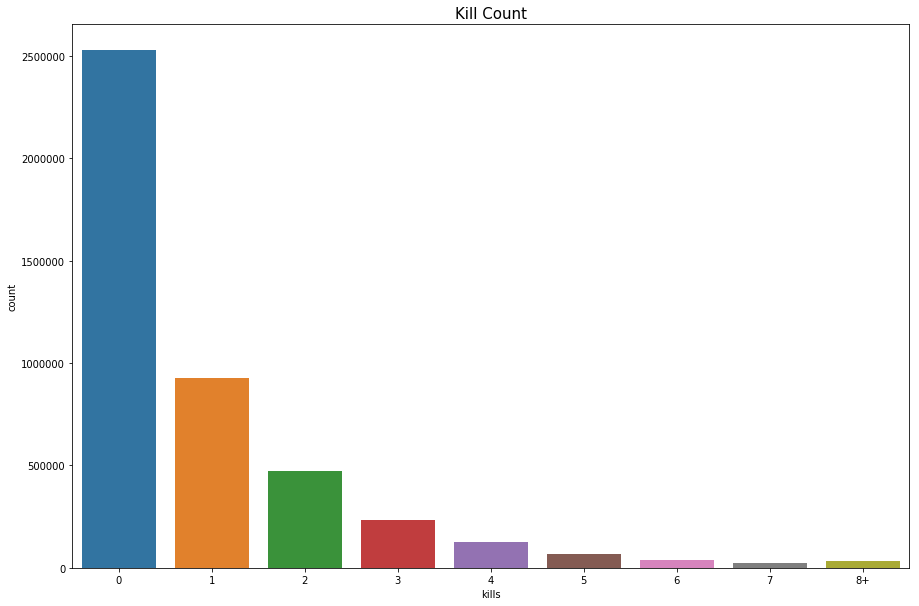

```python
data = train.copy()
data.loc[data['kills'] > data['kills'].quantile(0.99)] = '8+'
plt.figure(figsize=(15,10))
sns.countplot(data['kills'].astype('str').sort_values())
plt.title("Kill Count",fontsize=15)
plt.show()
```

Most people can't make a single kill. At least do they do damage?

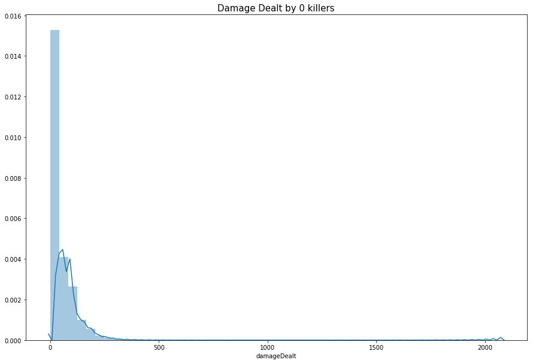

```python
data = train.copy()
data = data[data['kills']==0]
plt.figure(figsize=(15,10))
plt.title("Damage Dealt by 0 killers",fontsize=15)
sns.distplot(data['damageDealt'])
plt.show()
```

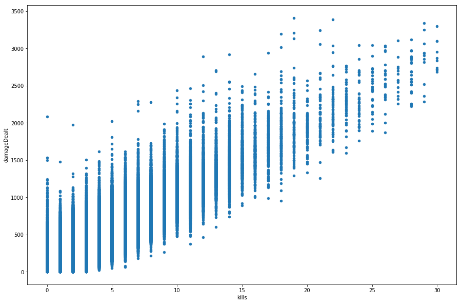

```python
train.plot(x="kills",y="damageDealt", kind="scatter", figsize = (15,10))
```

Well, most of them don't. Let's investigate the exceptions.

```python
print("{} players ({:.4f}%) have won without a single kill!".format(len(data[data['winPlacePerc']==1]), 100*len(data[data['winPlacePerc']==1])/len(train)))

data1 = train[train['damageDealt'] == 0].copy()
print("{} players ({:.4f}%) have won without dealing damage!".format(len(data1[data1['winPlacePerc']==1]), 100*len(data1[data1['winPlacePerc']==1])/len(train)))
```

```
16661 players (0.3748%) have won without a single kill!
4769 players (0.1073%) have won without dealing damage!
```

Plot win placement percentage vs kills.

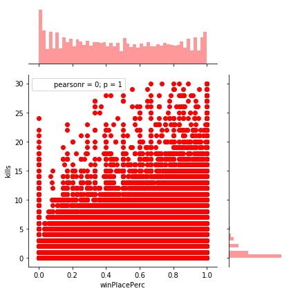

```python
sns.jointplot(x="winPlacePerc", y="kills", data=train, ratio=3, color="r")
plt.show()
```

Apparentrly killing has a correlation with winning. Finally let's group players based on kills (0 kills, 1-2 kills, 3-5 kills, 6-10 kills and 10+ kills).

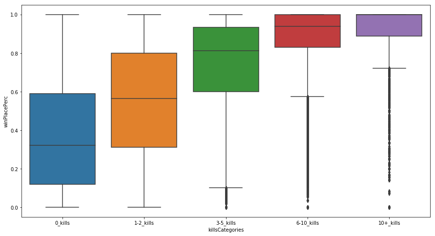

```python
kills = train.copy()

kills['killsCategories'] = pd.cut(kills['kills'], [-1, 0, 2, 5, 10, 60], labels=['0_kills','1-2_kills', '3-5_kills', '6-10_kills', '10+_kills'])

plt.figure(figsize=(15,8))
sns.boxplot(x="killsCategories", y="winPlacePerc", data=kills)
plt.show()
```

Lets Look at relation between DBNO and kills

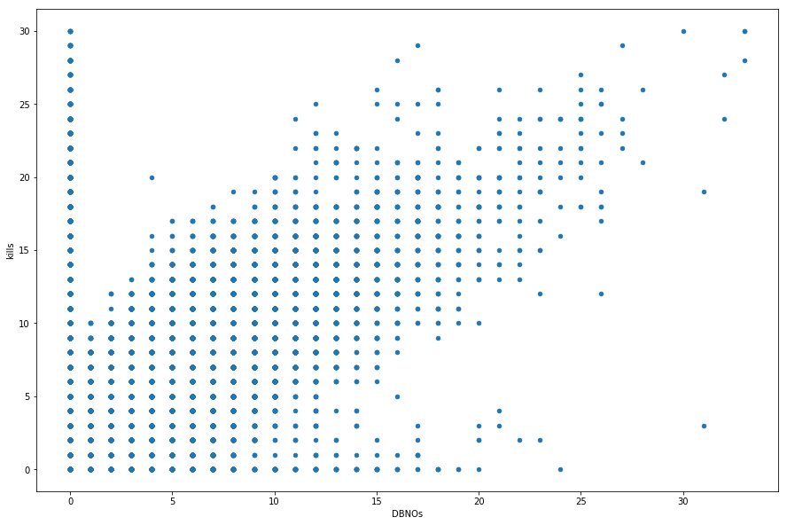

```python
train.plot(x="DBNOs",y="kills", kind="scatter", figsize = (15,10))
```

## Analysis on the basis of distance run

[figure not shown]

```python
print("The average person walks for {:.1f}m, 99% of people have walked {}m or less, while the marathoner champion walked for {}m.".format(train['walkDistance'].mean(), train['walkDistance'].quantile(0.99), train['walkDistance'].max()))
```

```
The average person walks for nanm, 99% of people have walked 4392.0m or less, while the marathoner champion walked for 9992.0m.
```

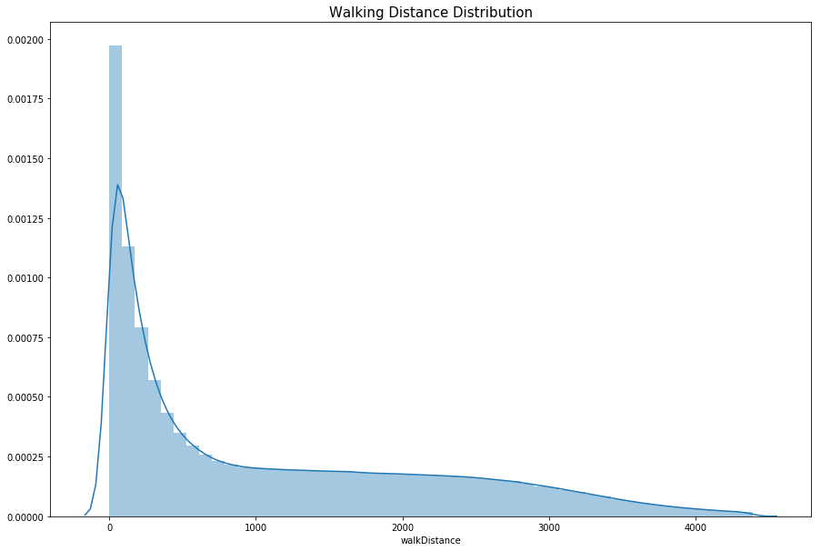

```python
data = train.copy()
data = data[data['walkDistance'] < train['walkDistance'].quantile(0.99)]
plt.figure(figsize=(15,10))
plt.title("Walking Distance Distribution",fontsize=15)
sns.distplot(data['walkDistance'])
plt.show()
```

```python
print("{} players ({:.4f}%) walked 0 meters. This means that they die before even taking a step or they are afk (more possible).".format(len(data[data['walkDistance'] == 0]), 100*len(data1[data1['walkDistance']==0])/len(train)))
```

```
98067 players (2.0338%) walked 0 meters. This means that they die before even taking a step or they are afk (more possible).
```

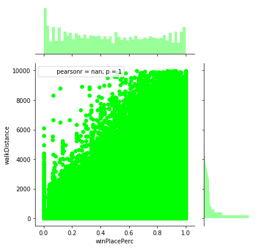

```python
sns.jointplot(x="winPlacePerc", y="walkDistance",  data=train, ratio=3, color="lime")
```

Apparently walking has a high correlation with winPlacePerc.

## Analysis on the basis of driving vehicles

[figure not shown]

```python
print("The average person drives for {:.1f}m, 99% of people have drived {}m or less, while the formula 1 champion drived for {}m.".format(train['rideDistance'].mean(), train['rideDistance'].quantile(0.99), train['rideDistance'].max()))
```

```
The average person drives for nanm, 99% of people have drived 6960.0m or less, while the formula 1 champion drived for 19936.0m.
```

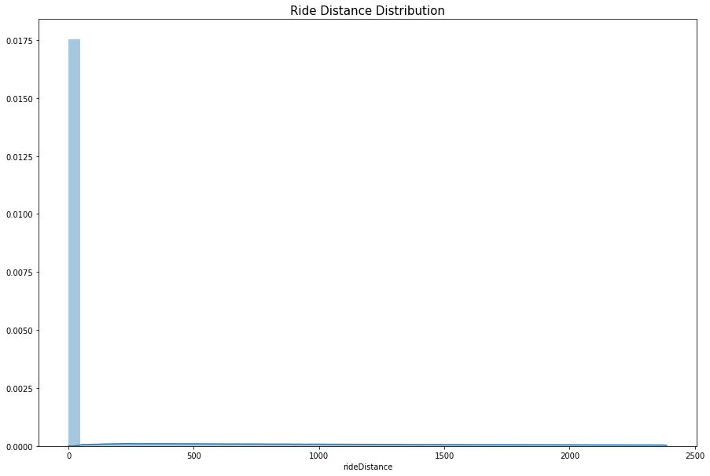

```python
data = train.copy()
data = data[data['rideDistance'] < train['rideDistance'].quantile(0.9)]
plt.figure(figsize=(15,10))
plt.title("Ride Distance Distribution",fontsize=15)
sns.distplot(data['rideDistance'])
plt.show()
```

```python
print("{} players ({:.4f}%) drived for 0 meters. This means that they don't have a driving licence yet.".format(len(data[data['rideDistance'] == 0]), 100*len(data1[data1['rideDistance']==0])/len(train)))
```

```
3307746 players (23.1129%) drived for 0 meters. This means that they don't have a driving licence yet.
```

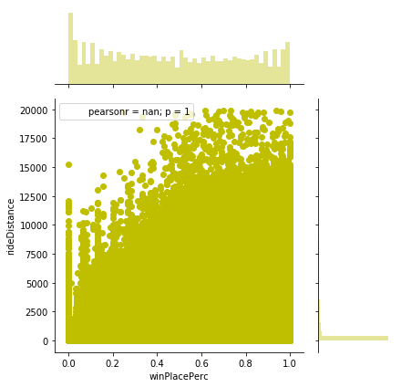

```python
sns.jointplot(x="winPlacePerc", y="rideDistance", data=train, ratio=3, color="y")
plt.show()
```

There is a small correlation between rideDistance and winPlacePerc.

Destroying a vehicle in shows that a player has skills. Let's check it.

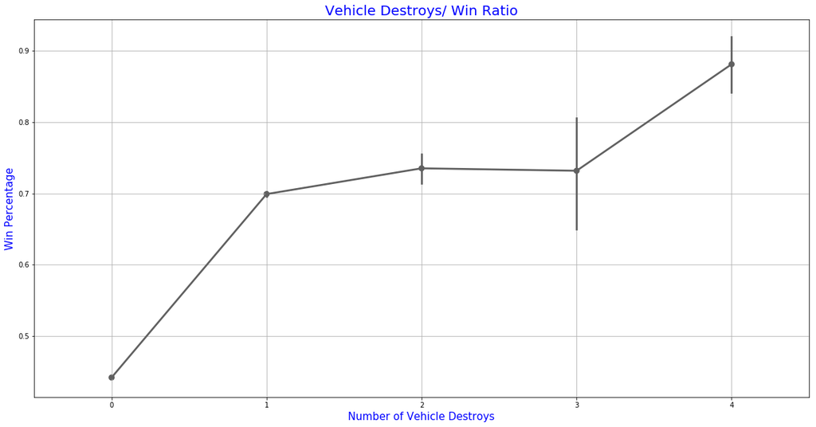

```python
f,ax1 = plt.subplots(figsize =(20,10))
sns.pointplot(x='vehicleDestroys',y='winPlacePerc',data=data,color='#606060',alpha=0.8)
plt.xlabel('Number of Vehicle Destroys',fontsize = 15,color='blue')
plt.ylabel('Win Percentage',fontsize = 15,color='blue')
plt.title('Vehicle Destroys/ Win Ratio',fontsize = 20,color='blue')
plt.grid()
plt.show()
```

Destroying a single vehicle increases your chances of winning!

## Analysis on the baisis of swim distance

[figure not shown]

```python
print("The average person swims for {:.1f}m, 99% of people have swimemd {}m or less, while the olympic champion swimmed for {}m.".format(train['swimDistance'].mean(), train['swimDistance'].quantile(0.99), train['swimDistance'].max()))
```

```
The average person swims for nanm, 99% of people have swimemd 122.875m or less, while the olympic champion swimmed for 1980.0m.
```

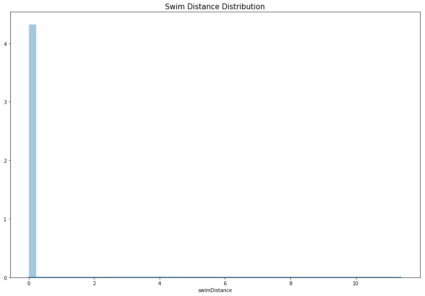

```python
data = train.copy()
data = data[data['swimDistance'] < train['swimDistance'].quantile(0.95)]
plt.figure(figsize=(15,10))
plt.title("Swim Distance Distribution",fontsize=15)
sns.distplot(data['swimDistance'])
plt.show()
```

Almost no one swims. Let's group the swimming distances in 4 categories and plot vs winPlacePerc.

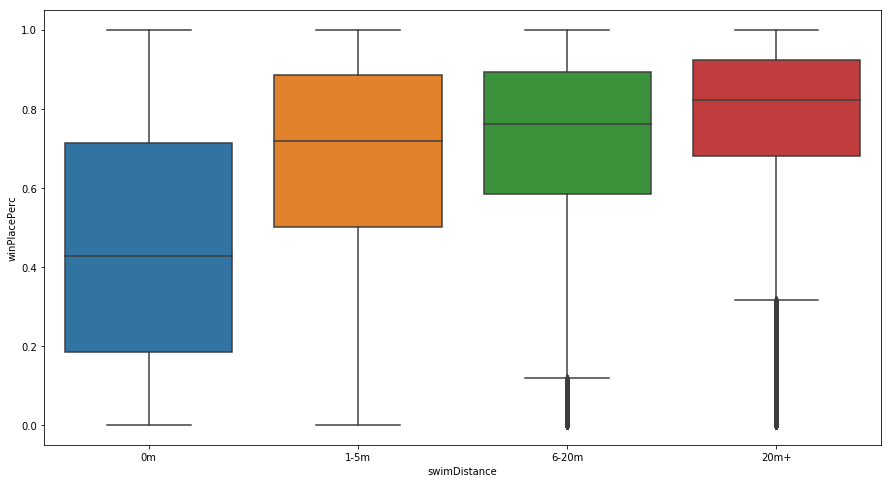

```python
swim = train.copy()

swim['swimDistance'] = pd.cut(swim['swimDistance'], [-1, 0, 5, 20, 5286], labels=['0m','1-5m', '6-20m', '20m+'])

plt.figure(figsize=(15,8))
sns.boxplot(x="swimDistance", y="winPlacePerc", data=swim)
plt.show()
```

It seems that if you swim, you rise to the top. In PUBG there are currently 3 maps. One of them has almost no water.

## Usinge heal & boost vs winning percentage

[figure not shown]

```python
print("The average person uses {:.1f} heal items, 99% of people use {} or less, while the doctor used {}.".format(train['heals'].mean(), train['heals'].quantile(0.99), train['heals'].max()))
print("The average person uses {:.1f} boost items, 99% of people use {} or less, while the doctor used {}.".format(train['boosts'].mean(), train['boosts'].quantile(0.99), train['boosts'].max()))
```

```
The average person uses 1.4 heal items, 99% of people use 12.0 or less, while the doctor used 39.
The average person uses 1.1 boost items, 99% of people use 7.0 or less, while the doctor used 33.
```

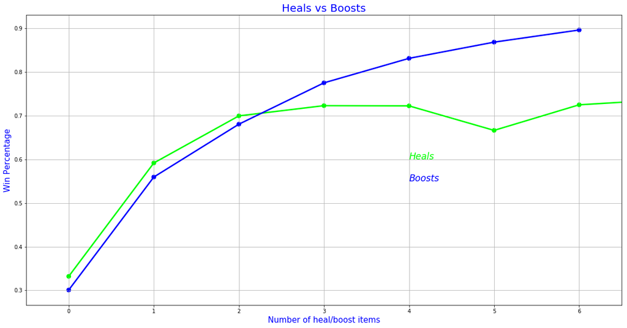

```python
data = train.copy()
data = data[data['heals'] < data['heals'].quantile(0.99)]
data = data[data['boosts'] < data['boosts'].quantile(0.99)]

f,ax1 = plt.subplots(figsize =(20,10))
sns.pointplot(x='heals',y='winPlacePerc',data=data,color='lime',alpha=0.8)
sns.pointplot(x='boosts',y='winPlacePerc',data=data,color='blue',alpha=0.8)
plt.text(4,0.6,'Heals',color='lime',fontsize = 17,style = 'italic')
plt.text(4,0.55,'Boosts',color='blue',fontsize = 17,style = 'italic')
plt.xlabel('Number of heal/boost items',fontsize = 15,color='blue')
plt.ylabel('Win Percentage',fontsize = 15,color='blue')
plt.title('Heals vs Boosts',fontsize = 20,color='blue')
plt.grid()
plt.show()
```

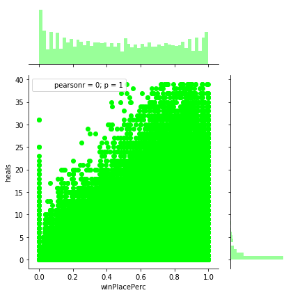

```python
sns.jointplot(x="winPlacePerc", y="heals", data=train, ratio=3, color="lime")
plt.show()
```

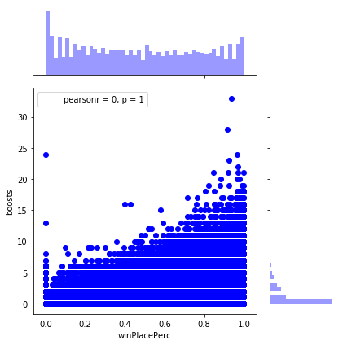

```python
sns.jointplot(x="winPlacePerc", y="boosts", data=train, ratio=3, color="blue")
plt.show()
```

So healing and boosting, definitely are correlated with winPlacePerc. Boosting is more.

In every plot, there is an abnormal behavior when values are 0.

## Analysis in different modes of play- Solos, Duos and Squads

There are 3 game modes in the game. One can play solo, or with a friend (duo), or with 3 other friends (squad). 100 players join the same server, so in the case of duos the max teams are 50 and in the case of squads the max teams are 25.

```python
solos = train[train['numGroups']>50]
duos = train[(train['numGroups']>25) & (train['numGroups']<=50)]
squads = train[train['numGroups']<=25]
print("There are {} ({:.2f}%) solo games, {} ({:.2f}%) duo games and {} ({:.2f}%) squad games.".format(len(solos), 100*len(solos)/len(train), len(duos), 100*len(duos)/len(train), len(squads), 100*len(squads)/len(train),))
```

```
There are 708741 (15.95%) solo games, 3294962 (74.13%) duo games and 441073 (9.92%) squad games.
```

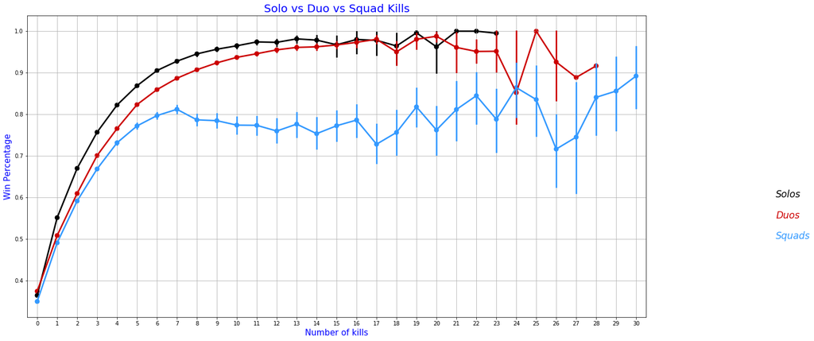

```python
f,ax1 = plt.subplots(figsize =(20,10))
sns.pointplot(x='kills',y='winPlacePerc',data=solos,color='black',alpha=0.8)
sns.pointplot(x='kills',y='winPlacePerc',data=duos,color='#CC0000',alpha=0.8)
sns.pointplot(x='kills',y='winPlacePerc',data=squads,color='#3399FF',alpha=0.8)
plt.text(37,0.6,'Solos',color='black',fontsize = 17,style = 'italic')
plt.text(37,0.55,'Duos',color='#CC0000',fontsize = 17,style = 'italic')
plt.text(37,0.5,'Squads',color='#3399FF',fontsize = 17,style = 'italic')
plt.xlabel('Number of kills',fontsize = 15,color='blue')
plt.ylabel('Win Percentage',fontsize = 15,color='blue')
plt.title('Solo vs Duo vs Squad Kills',fontsize = 20,color='blue')
plt.grid()
plt.show()
```

Solos and duos behave the same, but when playing squads kills don't matter that much.

The attribute DBNOs means enemy players knocked. A "knock" can happen only in duos or squads, because the teammates have the chance to "revive" the knocked player in a given time. So a knocked player can be revived or die. If he is revived, the next time he will be knocked, his teammates will have less time to revive him.

The attribute assist can also happen only in duos or squads. It generally means that the player had an involvement in a kill.

The attribute revive also happens in duos or squads.

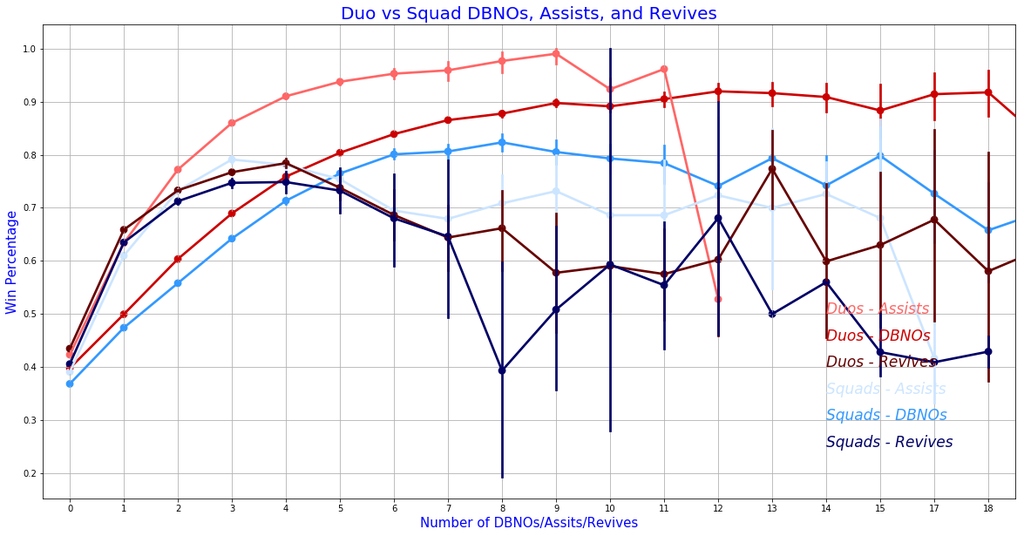

```python
f,ax1 = plt.subplots(figsize =(20,10))
sns.pointplot(x='DBNOs',y='winPlacePerc',data=duos,color='#CC0000',alpha=0.8)
sns.pointplot(x='DBNOs',y='winPlacePerc',data=squads,color='#3399FF',alpha=0.8)
sns.pointplot(x='assists',y='winPlacePerc',data=duos,color='#FF6666',alpha=0.8)
sns.pointplot(x='assists',y='winPlacePerc',data=squads,color='#CCE5FF',alpha=0.8)
sns.pointplot(x='revives',y='winPlacePerc',data=duos,color='#660000',alpha=0.8)
sns.pointplot(x='revives',y='winPlacePerc',data=squads,color='#000066',alpha=0.8)
plt.text(14,0.5,'Duos - Assists',color='#FF6666',fontsize = 17,style = 'italic')
plt.text(14,0.45,'Duos - DBNOs',color='#CC0000',fontsize = 17,style = 'italic')
plt.text(14,0.4,'Duos - Revives',color='#660000',fontsize = 17,style = 'italic')
plt.text(14,0.35,'Squads - Assists',color='#CCE5FF',fontsize = 17,style = 'italic')
plt.text(14,0.3,'Squads - DBNOs',color='#3399FF',fontsize = 17,style = 'italic')
plt.text(14,0.25,'Squads - Revives',color='#000066',fontsize = 17,style = 'italic')
plt.xlabel('Number of DBNOs/Assits/Revives',fontsize = 15,color='blue')
plt.ylabel('Win Percentage',fontsize = 15,color='blue')
plt.title('Duo vs Squad DBNOs, Assists, and Revives',fontsize = 20,color='blue')
plt.grid()
plt.show()
```

```
TOP 10% overview

Average number of kills: 2.6
Minimum: 0
The best: 30
95% of players within: 7.0 kills.
```

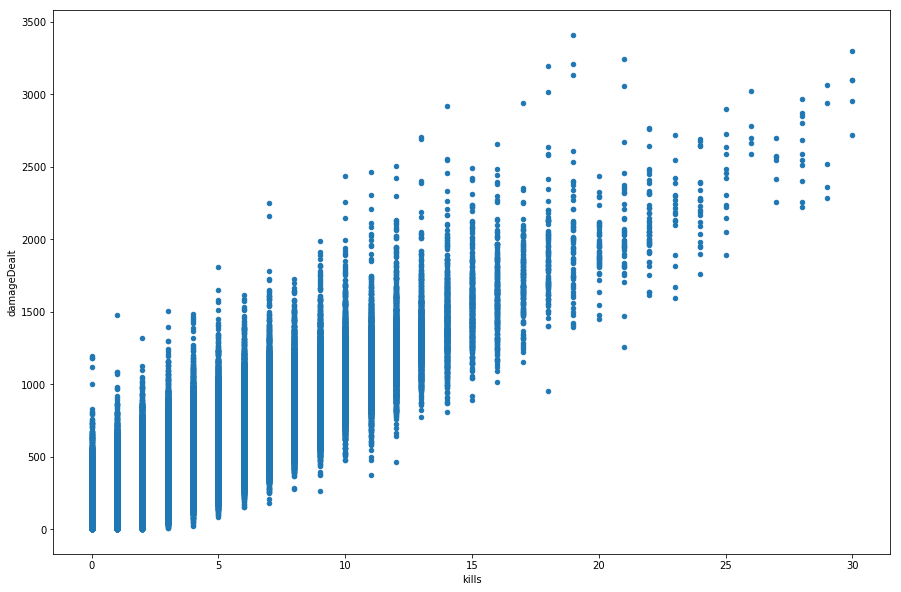

```python
top10 = train[train["winPlacePerc"]>0.9]
print("TOP 10% overview\n")
print("Average number of kills: {:.1f}\nMinimum: {}\nThe best: {}\n95% of players within: {} kills."
      .format(top10["kills"].mean(), top10["kills"].min(), top10["kills"].max(),top10["kills"].quantile(0.95)))

top10.plot(x="kills", y="damageDealt", kind="scatter", figsize = (15,10))
```

## Calculating correlation between variables

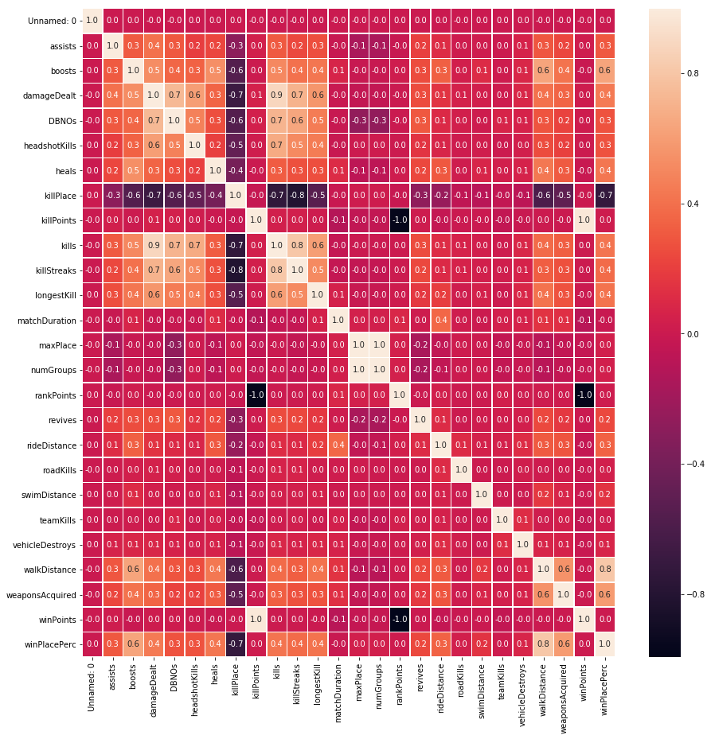

```python
f,ax = plt.subplots(figsize=(15, 15))
sns.heatmap(train.corr(), annot=True, linewidths=.5, fmt= '.1f',ax=ax)
plt.show()
```

In terms of the target variable (winPlacePerc), there are a few variables high medium to high correlation. The highest positive correlation is walkDistance and the highest negative the killPlace.

**Let's zoom to the top-5 most positive correlated variables with the target.**

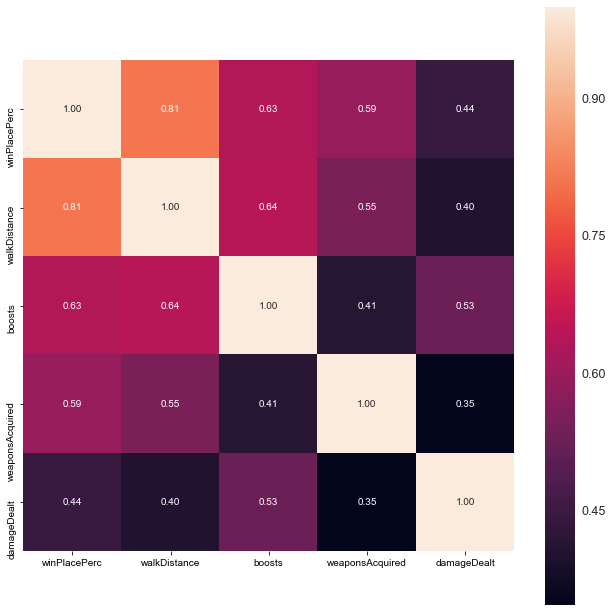

```python
k = 5 #number of variables for heatmap
f,ax = plt.subplots(figsize=(11, 11))
cols = train.corr().nlargest(k, 'winPlacePerc')['winPlacePerc'].index
cm = np.corrcoef(train[cols].values.T)
sns.set(font_scale=1.25)
hm = sns.heatmap(cm, cbar=True, annot=True, square=True, fmt='.2f', annot_kws={'size': 10}, yticklabels=cols.values, xticklabels=cols.values)
plt.show()
```

Let's plot the above variables and the killPlace variable as pairs.

```python
train.replace(np.nan, 0)
```

[output not shown]

4444776 rows × 30 columns

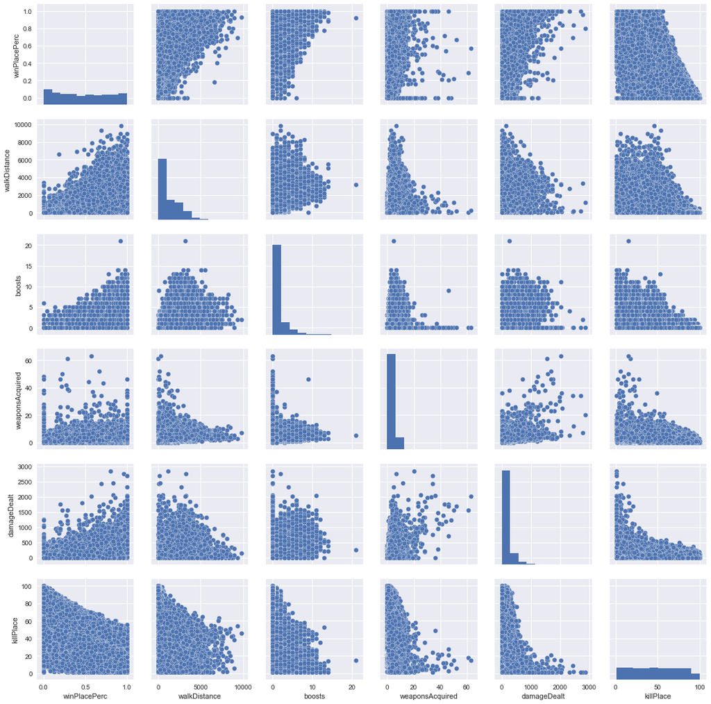

```python
sns.set()
cols = ['winPlacePerc', 'walkDistance', 'boosts', 'weaponsAcquired', 'damageDealt', 'killPlace'
       ]
test_data=train[cols]
test_data.shape

exp = test_data[:][0:100000]

sns.pairplot(exp,size=2.5)
plt.show()
```

# Feature Engineering

A game in PUBG can have up to 100 players fighting each other. But most of the times a game isn't "full". There is no variable that gives us the number of players joined. So lets create one.

### Feature importances of Tree models

Tree models can output feature importances.

```python
def train_test_split(df, test_size=0.1):
    match_ids = df['matchId'].unique().tolist()
    train_size = int(len(match_ids) * (1 - test_size))
    train_match_ids = random.sample(match_ids, train_size)

    train = df[df['matchId'].isin(train_match_ids)]
    test = df[-df['matchId'].isin(train_match_ids)]

    return train, test
```

```
[20]	valid_0's l1: 0.0655281
[40]	valid_0's l1: 0.0619548
[60]	valid_0's l1: 0.0607947
[80]	valid_0's l1: 0.0601366
[100]	valid_0's l1: 0.0598067
```

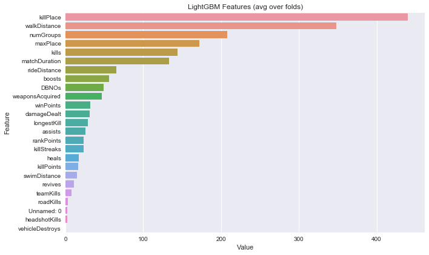

```python
df = reload()

target = 'winPlacePerc'
cols_to_drop = ['Id', 'groupId', 'matchId', 'matchType', target]
cols_to_fit = [col for col in df.columns if col not in cols_to_drop]
train, val = train_test_split(df, 0.1)

params = {
    'n_estimators': 100,
    'learning_rate': 0.3,
    'num_leaves': 20,
    'objective': 'regression_l2',
    'metric': 'mae',
    'verbose': -1,
}

model = LGBMRegressor(**params)
model.fit(
    train[cols_to_fit], train[target],
    eval_set=[(val[cols_to_fit], val[target])],
    eval_metric='mae',
    verbose=20,
)

feature_importance = pd.DataFrame(sorted(zip(model.feature_importances_, cols_to_fit)), columns=['Value','Feature'])

plt.figure(figsize=(10, 6))
sns.barplot(x="Value", y="Feature", data=feature_importance.sort_values(by="Value", ascending=False))
plt.title('LightGBM Features (avg over folds)')
plt.tight_layout()
```

```python
train['playersJoined'] = train.groupby('matchId')['matchId'].transform('count')
```

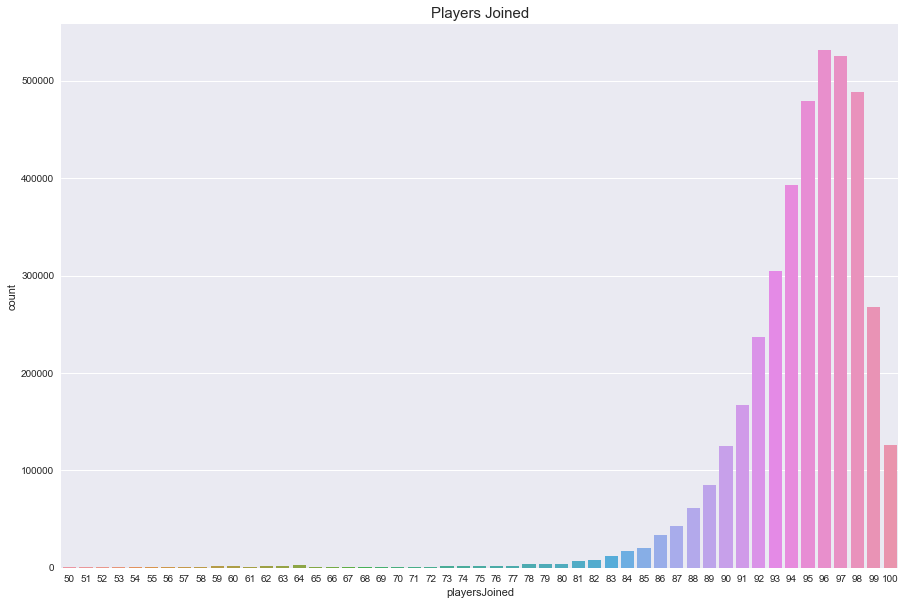

```python
data = train.copy()
data = data[data['playersJoined']>49]
plt.figure(figsize=(15,10))
sns.countplot(data['playersJoined'])
plt.title("Players Joined",fontsize=15)
plt.show()
```

Based on the "playersJoined" feature we can create (or change) a lot of others to normalize their values. For example i will create the "killsNorm" and "damageDealtNorm" features. When there are 100 players in the game it might be easier to find and kill someone, than when there are 90 players. So i will normalize the kills in a way that a kill in 100 players will score 1 (as it is) and in 90 players it will score (100-90)/100 + 1 = 1.1. This is just an assumption. You can use different scales.

```python
train['killsNorm'] = train['kills']*((100-train['playersJoined'])/100 + 1)
train['damageDealtNorm'] = train['damageDealt']*((100-train['playersJoined'])/100 + 1)
train[['playersJoined', 'kills', 'killsNorm', 'damageDealt', 'damageDealtNorm']][5:8]
```

|  | playersJoined | kills | killsNorm | damageDealt | damageDealtNorm |
| --- | --- | --- | --- | --- | --- |
| 5 | 95 | 1 | 1.05 | 100.000 | 105.00000 |
| 6 | 97 | 0 | 0.00 | 0.000 | 0.00000 |
| 7 | 96 | 0 | 0.00 | 8.538 | 8.87952 |

Another simple feature is the sum of heals and boosts. Also the sum of total distance travelled.

```python
train['healsAndBoosts'] = train['heals']+train['boosts']
train['totalDistance'] = train['walkDistance']+train['rideDistance']+train['swimDistance']
```

When using boosting items you run faster. They also help staying out of the zone (PUBG term) and loot more (meaning walking more). So lets create a feature boosts per walking distance. Heals don't make you run faster, but they also help staying out of the zone and loot more. So lets create the same feature for heals also.

```python
train['boostsPerWalkDistance'] = train['boosts']/(train['walkDistance']+1) #The +1 is to avoid infinity, because there are entries where boosts>0 and walkDistance=0. Strange.
train['boostsPerWalkDistance'].fillna(0, inplace=True)
train['healsPerWalkDistance'] = train['heals']/(train['walkDistance']+1) #The +1 is to avoid infinity, because there are entries where heals>0 and walkDistance=0. Strange.
train['healsPerWalkDistance'].fillna(0, inplace=True)
train['healsAndBoostsPerWalkDistance'] = train['healsAndBoosts']/(train['walkDistance']+1) #The +1 is to avoid infinity.
train['healsAndBoostsPerWalkDistance'].fillna(0, inplace=True)
train[['walkDistance', 'boosts', 'boostsPerWalkDistance' ,'heals',  'healsPerWalkDistance', 'healsAndBoosts', 'healsAndBoostsPerWalkDistance']][40:45]
```

|  | walkDistance | boosts | boostsPerWalkDistance | heals | healsPerWalkDistance | healsAndBoosts | healsAndBoostsPerWalkDistance |
| --- | --- | --- | --- | --- | --- | --- | --- |
| 41 | 128.80 | 0 | 0.000000 | 0 | 0.000000 | 0 | 0.000000 |
| 42 | 52.52 | 0 | 0.000000 | 0 | 0.000000 | 0 | 0.000000 |
| 43 | 534.10 | 1 | 0.001869 | 0 | 0.000000 | 1 | 0.001869 |
| 44 | 2576.00 | 4 | 0.001552 | 6 | 0.002328 | 10 | 0.003880 |
| 46 | 68.56 | 0 | 0.000000 | 0 | 0.000000 | 0 | 0.000000 |

Same, let's create the feature "killsPerWalkDistance".

```python
train['killsPerWalkDistance'] = train['kills']/(train['walkDistance']+1) #The +1 is to avoid infinity, because there are entries where kills>0 and walkDistance=0. Strange.
train['killsPerWalkDistance'].fillna(0, inplace=True)
train[['kills', 'walkDistance', 'rideDistance', 'killsPerWalkDistance', 'winPlacePerc']].sort_values(by='killsPerWalkDistance').tail(10)
```

|  | kills | walkDistance | rideDistance | killsPerWalkDistance | winPlacePerc |
| --- | --- | --- | --- | --- | --- |
| 1580039 | 16 | 5.8720 | 0.0 | 2.328289 | 0.6957 |
| 4179514 | 21 | 7.7590 | 0.0 | 2.397534 | 0.8000 |
| 3048331 | 13 | 4.2410 | 0.0 | 2.480443 | 0.6667 |
| 3216025 | 12 | 3.5270 | 0.0 | 2.650762 | 0.0000 |
| 4201230 | 19 | 6.0040 | 0.0 | 2.712736 | 0.4000 |
| 2444148 | 16 | 4.7380 | 0.0 | 2.788428 | 0.9167 |
| 2723399 | 11 | 2.8470 | 0.0 | 2.859371 | 0.6667 |
| 2906183 | 3 | 0.0000 | 1277.0 | 3.000000 | 0.4000 |
| 4196445 | 4 | 0.0000 | 0.0 | 4.000000 | 0.0000 |
| 2744974 | 6 | 0.4674 | 0.0 | 4.088865 | 0.7857 |

Earlier in the kernel we did EDA for Solos, Duos and Squads. Lets create a column for them.

```python
train['team'] = [1 if i>50 else 2 if (i>25 & i<=50) else 4 for i in train['numGroups']]
```

```python
train.head()
```

|  | Unnamed: 0 | Id | groupId | matchId | assists | boosts | damageDealt | DBNOs | headshotKills | heals | ... | playersJoined | killsNorm | damageDealtNorm | healsAndBoosts | totalDistance | boostsPerWalkDistance | healsPerWalkDistance | healsAndBoostsPerWalkDistance | killsPerWalkDistance | team |
| --- | --- | --- | --- | --- | --- | --- | --- | --- | --- | --- | --- | --- | --- | --- | --- | --- | --- | --- | --- | --- | --- |
| 0 | 0 | 7f96b2f878858a | 4d4b580de459be | a10357fd1a4a91 | 0 | 0 | 0.00 | 0 | 0 | 0 | ... | 96 | 0.00 | 0.0000 | 0 | 244.8000 | 0.0 | 0.0 | 0.0 | 0.000000 | 2 |
| 1 | 1 | eef90569b9d03c | 684d5656442f9e | aeb375fc57110c | 0 | 0 | 91.47 | 0 | 0 | 0 | ... | 91 | 0.00 | 99.7023 | 0 | 1445.0445 | 0.0 | 0.0 | 0.0 | 0.000000 | 4 |
| 2 | 2 | 1eaf90ac73de72 | 6a4a42c3245a74 | 110163d8bb94ae | 1 | 0 | 68.00 | 0 | 0 | 0 | ... | 98 | 0.00 | 69.3600 | 0 | 161.8000 | 0.0 | 0.0 | 0.0 | 0.000000 | 2 |
| 3 | 3 | 4616d365dd2853 | a930a9c79cd721 | f1f1f4ef412d7e | 0 | 0 | 32.90 | 0 | 0 | 0 | ... | 91 | 0.00 | 35.8610 | 0 | 202.7000 | 0.0 | 0.0 | 0.0 | 0.000000 | 2 |
| 4 | 4 | 315c96c26c9aac | de04010b3458dd | 6dc8ff871e21e6 | 0 | 0 | 100.00 | 0 | 0 | 0 | ... | 97 | 1.03 | 103.0000 | 0 | 49.7500 | 0.0 | 0.0 | 0.0 | 0.019704 | 1 |

5 rows × 40 columns

### Permutation importance

The basic idea is that observing how much the score decreases when a feature is not available; the method is known as “permutation importance” or “Mean Decrease Accuracy (MDA)”.

```python
perm = PermutationImportance(model, random_state=42).fit(val[cols_to_fit], val[target])
eli5.show_weights(perm, feature_names=list(cols_to_fit))
```

| Weight | Feature |
| --- | --- |
| 1.4722 ± 0.0059 | killPlace |
| 0.3042 ± 0.0017 | walkDistance |
| 0.2020 ± 0.0008 | kills |
| 0.1261 ± 0.0006 | numGroups |
| 0.0833 ± 0.0005 | killStreaks |
| 0.0698 ± 0.0005 | maxPlace |
| 0.0301 ± 0.0003 | matchDuration |
| 0.0071 ± 0.0001 | rideDistance |
| 0.0061 ± 0.0001 | boosts |
| 0.0028 ± 0.0001 | weaponsAcquired |
| 0.0023 ± 0.0001 | DBNOs |
| 0.0013 ± 0.0001 | assists |
| 0.0010 ± 0.0000 | damageDealt |
| 0.0010 ± 0.0000 | heals |
| 0.0008 ± 0.0000 | winPoints |
| 0.0008 ± 0.0000 | rankPoints |
| 0.0005 ± 0.0001 | killPoints |
| 0.0004 ± 0.0000 | longestKill |
| 0.0003 ± 0.0000 | revives |
| 0.0001 ± 0.0000 | swimDistance |
| *… 5 more …* |  |

Now getting correlation between variables with respect to win place percent

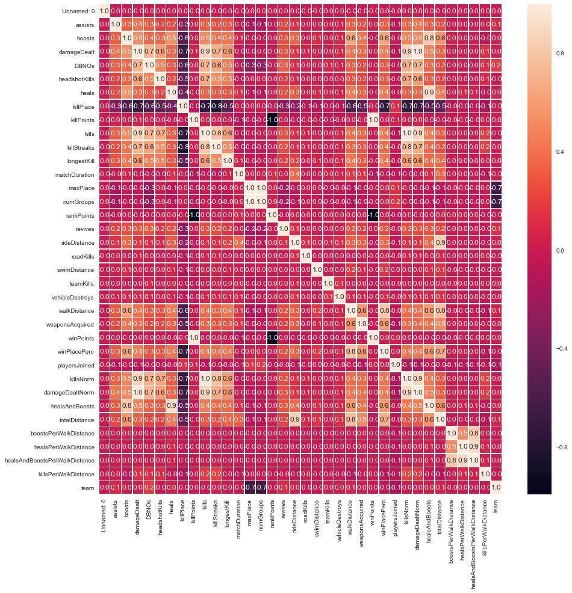

```python
f,ax = plt.subplots(figsize=(15, 15))
sns.heatmap(train.corr(), annot=True, linewidths=.5, fmt= '.1f',ax=ax)
plt.show()
```

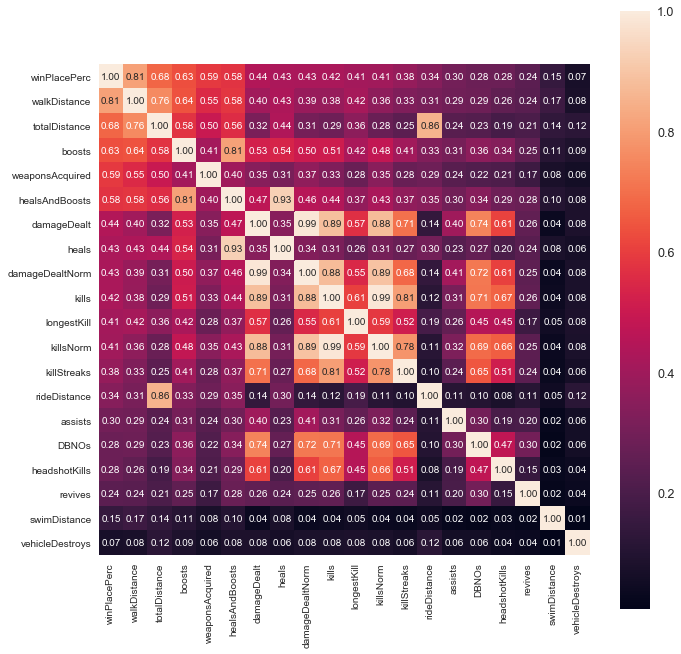

```python
k = 20 #number of variables for heatmap
f,ax = plt.subplots(figsize=(11, 11))
cols = train.corr().nlargest(k, 'winPlacePerc')['winPlacePerc'].index
cm = np.corrcoef(train[cols].values.T)
sns.set(font_scale=1.25)
hm = sns.heatmap(cm, cbar=True, annot=True, square=True, fmt='.2f', annot_kws={'size': 10}, yticklabels=cols.values, xticklabels=cols.values)
plt.show()
```

```python
train_df= train
train_df.shape
```

```
(4000662, 40)
```

```python
train_df=train_df.drop(['heals','killStreaks', 'boosts', 'kills', 'damageDealt', 'killPoints', 'rideDistance', 'walkDistance', 'swimDistance'
,'maxPlace','damageDealtNorm'], axis=1)
```

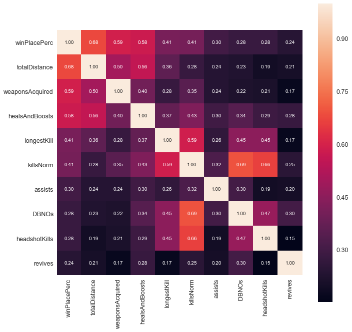

```python
k = 10 #number of variables for heatmap
f,ax = plt.subplots(figsize=(11, 11))
cols = train_df.corr().nlargest(k, 'winPlacePerc')['winPlacePerc'].index
cm = np.corrcoef(train_df[cols].values.T)
sns.set(font_scale=1.25)
hm = sns.heatmap(cm, cbar=True, annot=True, square=True, fmt='.2f', annot_kws={'size': 10}, yticklabels=cols.values, xticklabels=cols.values)
plt.show()
```

### SHAP values

SHAP proposed a new fair way to measure contribution which is justified in game theory.

[A Unified Approach to Interpreting Model Predictions](https://arxiv.org/pdf/1705.07874.pdf) (2017)

> Understanding why a model makes a certain prediction can be as crucial as the prediction’s accuracy in many applications. However, the highest accuracy for large modern datasets is often achieved by complex models that even experts struggle to interpret, such as ensemble or deep learning models, creating a tension between accuracy and interpretability.

Simple models are easy to interpret. They built a simple model which works well only on a local point (We don't need to predict on the all points). Then, use the simple model to interpret how it's trained.

[figure not shown]

This method was proposed in this paper: [“Why Should I Trust You?” Explaining the Predictions of Any Classifier](https://arxiv.org/pdf/1602.04938.pdf) (2016, known as LIME)

The main contribution of SHAP is that they introduced the concept of Shapley Value to measure the contribution.

Shapley Value is a solution concept in cooperative game theory, proposed in 1953 by [Lloyd Shapley](https://en.wikipedia.org/wiki/Lloyd_Shapley).

- Question: What is a "fair" way for a colition to divide its payoff?
  - Depends on the definition of "fairness"
- Approach: Identify axioms that express properties of a fair payoff division
  - Symmetry: Interchangeable agents should receive the same payments
  - Dummy Players: Dummy players should receive nothing
  - Additivity: $$(v_1 + v_2)(S) = v_1(S) + v_2(S)$$

The author of SHAP found that we can apply this concept to machine learning. In machine learning, *player* is *feature*, and *contribution* is *score*.

For example, we have 3 features L, M, and N. The shapley values are calculated like below.

[figure not shown]

It's the average of combinations of features. Intuitively, it sounds fair.

The implementation is available on GitHub: [slundberg/shap: A unified approach to explain the output of any machine learning model](https://github.com/slundberg/shap)

```python
shap.initjs()
```

```python
explainer = shap.TreeExplainer(model)
shap_values = explainer.shap_values(val[cols_to_fit])
```

SHAP values represent the fair score of features depending on their contribution towards the total score in the set of features.

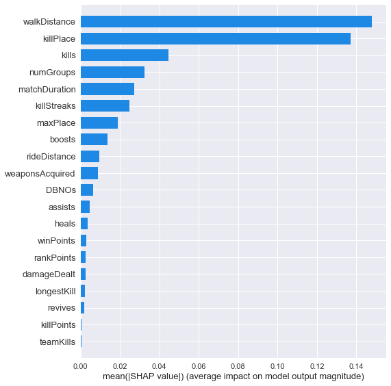

```python
shap.summary_plot(shap_values, val[cols_to_fit], plot_type='bar')
```

SHAP also can visualize how the score changes when the feature value is low/high on each data.

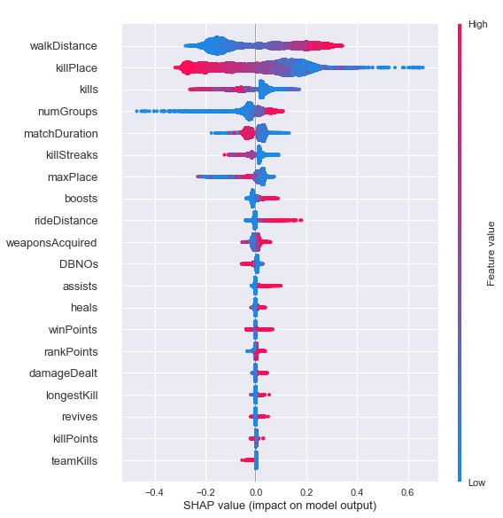

```python
shap.summary_plot(shap_values, val[cols_to_fit], feature_names=cols_to_fit)
```

Final variables selected to run ML models

```python
cols=['totalDistance', 'weaponsAcquired', 'healsAndBoosts', 'longestKill', 'killsNorm', 'assists','DBNOs', 'headshotKills',
                      'revives','vehicleDestroys','winPlacePerc','killPlace','numGroups']
final_train=train_df[cols]
final_train[['totalDistance', 'healsAndBoosts', 'killsNorm']]=final_train[['totalDistance',
                                                                           'healsAndBoosts', 'killsNorm']].astype('float64')
```

```python
final_train.head()
```

|  | totalDistance | weaponsAcquired | healsAndBoosts | longestKill | killsNorm | assists | DBNOs | headshotKills | revives | vehicleDestroys | winPlacePerc | killPlace | numGroups |
| --- | --- | --- | --- | --- | --- | --- | --- | --- | --- | --- | --- | --- | --- |
| 0 | 244.8000 | 1 | 0.0 | 0.00 | 0.00 | 0 | 0 | 0 | 0 | 0 | 0.4444 | 60 | 26 |
| 1 | 1445.0445 | 5 | 0.0 | 0.00 | 0.00 | 0 | 0 | 0 | 0 | 0 | 0.6400 | 57 | 25 |
| 2 | 161.8000 | 2 | 0.0 | 0.00 | 0.00 | 1 | 0 | 0 | 0 | 0 | 0.7755 | 47 | 47 |
| 3 | 202.7000 | 3 | 0.0 | 0.00 | 0.00 | 0 | 0 | 0 | 0 | 0 | 0.1667 | 75 | 30 |
| 4 | 49.7500 | 2 | 0.0 | 58.53 | 1.03 | 0 | 0 | 0 | 0 | 0 | 0.1875 | 45 | 95 |

```python
final_train.shape
```

```
(4000662, 13)
```

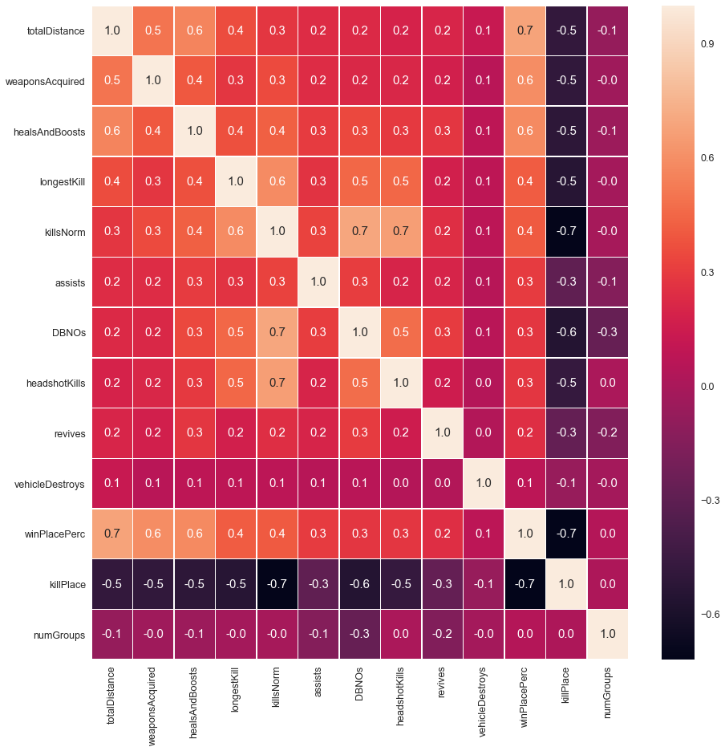

```python
f,ax = plt.subplots(figsize=(15, 15))
sns.heatmap(final_train.corr(), annot=True, linewidths=.5, fmt= '.1f',ax=ax)
plt.show()
```

```python
final_train.to_csv('final_train.csv')
```

```python
final_train.info()
```

```
<class 'pandas.core.frame.DataFrame'>
Int64Index: 4000662 entries, 0 to 4444775
Data columns (total 13 columns):
totalDistance      float64
weaponsAcquired    int64
healsAndBoosts     float64
longestKill        float64
killsNorm          float64
assists            int64
DBNOs              int64
headshotKills      int64
revives            int64
vehicleDestroys    int64
winPlacePerc       float64
killPlace          int64
numGroups          int64
dtypes: float64(5), int64(8)
memory usage: 427.3 MB
```